# R Notebook

```r
library(tidyverse)
library(janitor)
library(ggplot2)
library(GGally)
library(here)

neighbourhood_comp_data <- read_csv("data/complete_neighbourhood_rating.csv") %>% clean_names()
community_comp_data <- read_csv("data/complete_community_belonging.csv") %>% clean_names()
local_authority_codes <- read_csv("data/Local_Authority_Districts_Codes.csv") %>% clean_names()
green_blue_comp_data <- read_csv("data/complete_dist_blue_green.csv") %>% clean_names()
```

```r
scot_local_auth_codes <-
local_authority_codes %>%
  filter(str_detect(lad19cd, "S12")) %>%
  select(lad19cd, lad19nm) %>%
  rename(feature_code = lad19cd,
         local_authority = lad19nm)
```

```r
neigh_with_las_data <-
full_join(neighbourhood_comp_data, scot_local_auth_codes, "feature_code")

neigh_with_las_data <-
neigh_with_las_data %>%
  mutate(local_authority = if_else(feature_code == "S92000003", "Scotland", local_authority))

neigh_with_las_data
```

| feature_code | date_code | measurement | units | value | neighbourhood_rating | gender | urban_rural_classification | simd_quintiles | type_of_tenure | household_type | ethnicity | walking_distance_to_nearest_greenspace | local_authority |
| --- | --- | --- | --- | --- | --- | --- | --- | --- | --- | --- | --- | --- | --- |
| S12000008 | 2014 | 95% Upper Confidence Limit, Percent | Percent Of Adults | 60.7 | Very good | All | Urban | All | All | All | All | All | East Ayrshire |
| S12000026 | 2014 | 95% Upper Confidence Limit, Percent | Percent Of Adults | 51.8 | Fairly good | All | Urban | All | All | All | All | All | Scottish Borders |
| S12000020 | 2014 | 95% Lower Confidence Limit, Percent | Percent Of Adults | 0.0 | No opinion | All | Urban | All | All | All | All | All | Moray |
| S12000010 | 2017 | Percent | Percent Of Adults | 64.0 | Very good | All | Urban | All | All | All | All | All | East Lothian |
| S12000039 | 2017 | 95% Upper Confidence Limit, Percent | Percent Of Adults | 55.4 | Very good | All | Urban | All | All | All | All | All | West Dunbartonshire |
| S12000023 | 2019 | 95% Upper Confidence Limit, Percent | Percent Of Adults | 89.9 | Very good | All | Urban | All | All | All | All | All | Orkney Islands |
| S12000010 | 2017 | 95% Upper Confidence Limit, Percent | Percent Of Adults | 71.6 | Very good | All | Urban | All | All | All | All | All | East Lothian |
| S12000013 | 2017 | 95% Upper Confidence Limit, Percent | Percent Of Adults | 89.0 | Very good | All | Urban | All | All | All | All | All | Na h-Eileanan Siar |
| S12000033 | 2014 | Percent | Percent Of Adults | 1.0 | No opinion | All | Urban | All | All | All | All | All | Aberdeen City |
| S12000011 | 2017 | Percent | Percent Of Adults | 73.0 | Very good | All | Urban | All | All | All | All | All | East Renfrewshire |

[output cut: 990 more lines]

```r
commun_with_las_data <-
full_join(community_comp_data, scot_local_auth_codes, "feature_code")

commun_with_las_data <-
commun_with_las_data %>%
  mutate(local_authority = if_else(feature_code == "S92000003", "Scotland", local_authority))

commun_with_las_data
```

| feature_code | date_code | measurement | units | value | community_belonging | gender | urban_rural_classification | simd_quintiles | type_of_tenure | household_type | ethnicity | walking_distance_to_nearest_greenspace | local_authority |
| --- | --- | --- | --- | --- | --- | --- | --- | --- | --- | --- | --- | --- | --- |
| S12000030 | 2014 | Percent | Percent Of Adults | 44.0 | Very strongly | All | All | All | All | All | All | All | Stirling |
| S12000033 | 2014 | 95% Upper Confidence Limit, Percent | Percent Of Adults | 35.7 | Very strongly | All | All | All | All | All | All | All | Aberdeen City |
| S12000029 | 2014 | 95% Lower Confidence Limit, Percent | Percent Of Adults | 39.3 | Very strongly | All | All | All | All | All | All | All | South Lanarkshire |
| S12000029 | 2018 | Percent | Percent Of Adults | 2.0 | Don't know | All | All | 80% least deprived | All | All | All | All | South Lanarkshire |
| S12000017 | 2015 | 95% Lower Confidence Limit, Percent | Percent Of Adults | 0.0 | Not at all strongly | All | All | All | All | All | All | All | Highland |
| S12000029 | 2014 | 95% Upper Confidence Limit, Percent | Percent Of Adults | 50.2 | Very strongly | All | All | All | All | All | All | All | South Lanarkshire |
| S12000035 | 2019 | Percent | Percent Of Adults | 8.0 | Not at all strongly | Male | All | All | All | All | All | All | Argyll and Bute |
| S12000035 | 2015 | 95% Upper Confidence Limit, Percent | Percent Of Adults | 33.3 | Not at all strongly | Male | All | All | All | All | All | All | Argyll and Bute |
| S12000035 | 2019 | Percent | Percent Of Adults | 7.0 | Not at all strongly | Female | All | All | All | All | All | All | Argyll and Bute |
| S12000049 | 2018 | Percent | Percent Of Adults | 7.0 | Not at all strongly | All | All | All | All | All | All | More than 10 minutes | Glasgow City |

[output cut: 990 more lines]

```r
commun_filtered <-
commun_with_las_data %>%
  filter(measurement == "Percent") %>%
  select(-c(feature_code, units, measurement))

neigh_filtered <-
neigh_with_las_data %>%
  filter(measurement == "Percent") %>%
  select(-c(feature_code, units, measurement))
```

```r
neigh_filtered
```

| date_code | value | neighbourhood_rating | gender | urban_rural_classification | simd_quintiles | type_of_tenure | household_type | ethnicity | walking_distance_to_nearest_greenspace | local_authority |
| --- | --- | --- | --- | --- | --- | --- | --- | --- | --- | --- |
| 2017 | 64 | Very good | All | Urban | All | All | All | All | All | East Lothian |
| 2014 | 1 | No opinion | All | Urban | All | All | All | All | All | Aberdeen City |
| 2017 | 73 | Very good | All | Urban | All | All | All | All | All | East Renfrewshire |
| 2014 | 61 | Very good | All | Urban | All | All | All | All | All | Shetland Islands |
| 2014 | 1 | No opinion | All | Urban | All | All | All | All | All | City of Edinburgh |
| 2015 | 32 | Fairly good | All | Urban | All | All | All | All | All | Stirling |
| 2014 | 65 | Very good | All | Urban | All | All | All | All | All | Dumfries and Galloway |
| 2013 | 52 | Very good | All | Urban | All | All | All | All | All | Falkirk |
| 2017 | 1 | Very poor | All | All | All | All | All | All | All | Dumfries and Galloway |
| 2017 | 1 | Very poor | All | Urban | All | All | All | All | All | West Lothian |

[output cut: 990 more lines]

```r
commun_filtered
```

| date_code | value | community_belonging | gender | urban_rural_classification | simd_quintiles | type_of_tenure | household_type | ethnicity | walking_distance_to_nearest_greenspace | local_authority |
| --- | --- | --- | --- | --- | --- | --- | --- | --- | --- | --- |
| 2014 | 44 | Very strongly | All | All | All | All | All | All | All | Stirling |
| 2018 | 2 | Don't know | All | All | 80% least deprived | All | All | All | All | South Lanarkshire |
| 2019 | 8 | Not at all strongly | Male | All | All | All | All | All | All | Argyll and Bute |
| 2019 | 7 | Not at all strongly | Female | All | All | All | All | All | All | Argyll and Bute |
| 2018 | 7 | Not at all strongly | All | All | All | All | All | All | More than 10 minutes | Glasgow City |
| 2014 | 32 | Very strongly | All | All | All | All | All | All | All | East Lothian |
| 2014 | 42 | Very strongly | All | All | All | All | All | All | All | East Ayrshire |
| 2019 | 10 | Not at all strongly | Female | All | All | All | All | All | All | Aberdeen City |
| 2018 | 43 | Very strongly | All | All | All | All | All | All | More than 10 minutes | South Lanarkshire |
| 2015 | 5 | Not at all strongly | All | All | All | All | All | All | All | Inverclyde |

[output cut: 990 more lines]

```r
neigh_pivot_wide <-
neigh_filtered %>%
pivot_wider(names_prefix = "nr_", names_from = neighbourhood_rating, values_from = value)

commun_pivot_wide <-
commun_filtered %>%
pivot_wider(names_prefix = "com_bel_", names_from = community_belonging, values_from = value)
```

```r
#This may be slightly dodgy since we're not completely sure that the two data sets refer to the same individuals. We're probably going to end up with quite a lot of missing values as well

neigh_comm_original_join <-
full_join(neigh_pivot_wide, commun_pivot_wide) %>%
  clean_names()
```

```r
just_walking_distance_neigh_comm <-
neigh_comm_original_join %>%
  filter(walking_distance_to_nearest_greenspace != "All")

just_walking_distance_neigh_comm
```

| date_code | gender | urban_rural_classification | simd_quintiles | type_of_tenure | household_type | ethnicity | walking_distance_to_nearest_greenspace | local_authority | nr_very_good | nr_no_opinion | nr_fairly_good | nr_very_poor | nr_fairly_poor | com_bel_very_strongly | com_bel_dont_know | com_bel_not_at_all_strongly | com_bel_fairly_strongly | com_bel_not_very_strongly |
| --- | --- | --- | --- | --- | --- | --- | --- | --- | --- | --- | --- | --- | --- | --- | --- | --- | --- | --- |
| 2013 | All | All | All | All | All | All | More than 10 minutes | North Lanarkshire | 40 | NA | 45 | 4 | 11 | 28 | 1 | 13 | 36 | 21 |
| 2018 | All | All | All | All | All | All | More than 10 minutes | South Lanarkshire | 54 | NA | 36 | 8 | 2 | 43 | NA | 9 | 31 | 16 |
| 2017 | All | All | All | All | All | All | More than 10 minutes | Aberdeen City | 54 | 2 | 42 | 1 | 1 | 31 | 2 | 12 | 35 | 21 |
| 2018 | All | All | All | All | All | All | More than 10 minutes | Aberdeen City | 48 | NA | 38 | 5 | 8 | 24 | 3 | 5 | 45 | 23 |
| 2019 | All | All | All | All | All | All | More than 10 minutes | North Lanarkshire | 42 | NA | 47 | 1 | 10 | 36 | NA | 10 | 39 | 15 |
| 2018 | All | All | All | All | All | All | More than 10 minutes | Orkney Islands | 81 | NA | 19 | NA | NA | 58 | NA | NA | 36 | 6 |
| 2016 | All | All | All | All | All | All | More than 10 minutes | Aberdeenshire | 65 | NA | 32 | NA | 4 | 39 | 1 | 7 | 38 | 15 |
| 2013 | All | All | All | All | All | All | More than 10 minutes | South Lanarkshire | 47 | NA | 45 | 4 | 5 | 42 | NA | 4 | 38 | 16 |
| 2014 | All | All | All | All | All | All | More than 10 minutes | Glasgow City | 42 | 0 | 51 | 3 | 4 | 40 | 0 | 5 | 42 | 12 |
| 2019 | All | All | All | All | All | All | More than 10 minutes | Glasgow City | 38 | 1 | 54 | 3 | 4 | 31 | 3 | 9 | 36 | 20 |

[output cut: 290 more lines]

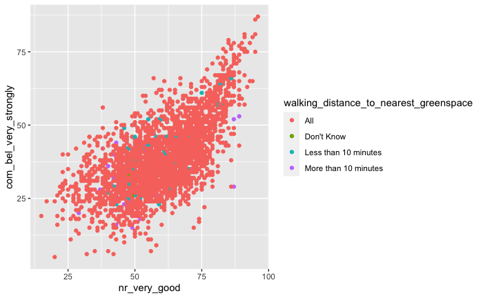

```r
neigh_comm_original_join %>%
  ggplot() +
  aes(x = nr_very_good, y = com_bel_very_strongly, color = walking_distance_to_nearest_greenspace) +
  geom_point()
```

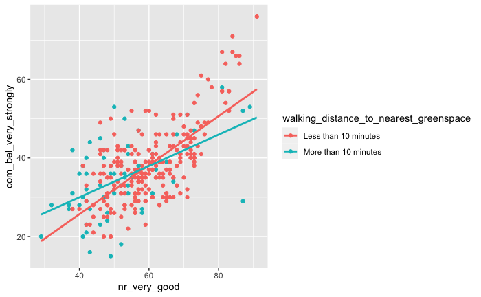

```r
#I quite like this particular graph and the next one as well, although the data probably needs to be cleaned up a bit to get Scotland averages out.
just_walking_distance_neigh_comm %>%
  filter(walking_distance_to_nearest_greenspace != "Don't Know") %>%
  ggplot() +
  aes(x = nr_very_good, y = com_bel_very_strongly, color = walking_distance_to_nearest_greenspace) +
  geom_point() +
  geom_smooth(method = lm, se = FALSE, fullrange = TRUE)
```

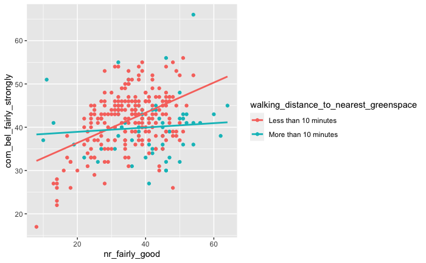

```r
#I quite like this particular graph, although the data probably needs to be cleaned up a bit to get Scotland averages out.
just_walking_distance_neigh_comm %>%
  filter(walking_distance_to_nearest_greenspace != "Don't Know") %>%
  ggplot() +
  aes(x = nr_fairly_good, y = com_bel_fairly_strongly, color = walking_distance_to_nearest_greenspace) +
  geom_point() +
  geom_smooth(method = lm, se = FALSE, fullrange = TRUE)
```

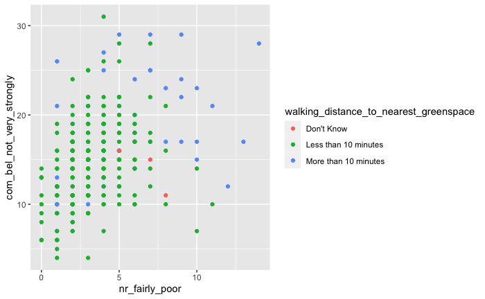

```r
just_walking_distance_neigh_comm %>%
  ggplot() +
  aes(x = nr_fairly_poor, y = com_bel_not_very_strongly, color = walking_distance_to_nearest_greenspace) +
  geom_point()
```

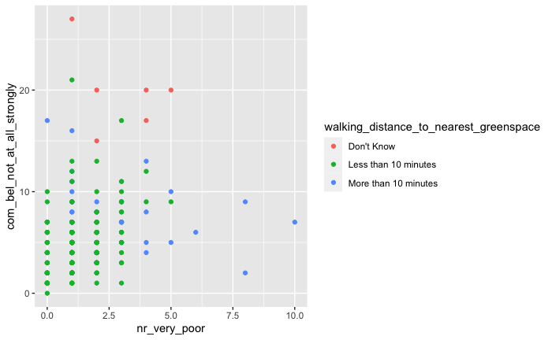

```r
just_walking_distance_neigh_comm %>%
  ggplot() +
  aes(x = nr_very_poor, y = com_bel_not_at_all_strongly, color = walking_distance_to_nearest_greenspace) +
  geom_point()
```

```r
write_csv(just_walking_distance_neigh_comm, "data/presentation_data/graph_10_11_just_walking_distance_neigh_comm.csv")
```

Cool, so we’ve plotted some of the relationships between the the neighbourhood ratings and the community belonging ratings, based on the fact that they both pretty much exist on a evenly spaced four-point scale (with an extra don’t know section each).

This is us trying out some of the extra pivots to see if we can shed any further light on the questions.

Now let’s see if we can add the green/blue space data and even if we can use all of this to start forming a model.

```r
gb_full_clean <-
full_join(green_blue_comp_data, scot_local_auth_codes, "feature_code") %>%
  mutate(local_authority = if_else(feature_code == "S92000003",
                                   "Scotland",
                                   local_authority)) %>%
  filter(measurement == "Percent") %>%
  select(-c(feature_code, units, measurement)) %>%
    pivot_wider(names_from = distance_to_nearest_green_or_blue_space,
              values_from = value) %>%
  clean_names() %>%
  mutate(less_than_11_mins = a_5_minute_walk_or_less + within_a_6_10_minute_walk)

gb_full_clean
```

| date_code | age | gender | urban_rural_classification | simd_quintiles | type_of_tenure | household_type | ethnicity | local_authority | within_a_6_10_minute_walk | an_11_minute_walk_or_more | a_5_minute_walk_or_less | dont_know | less_than_11_mins |
| --- | --- | --- | --- | --- | --- | --- | --- | --- | --- | --- | --- | --- | --- |
| 2013 | All | All | All | All | All | With Children | All | Stirling | 20 | 3 | 77 | NA | 97 |
| 2019 | All | All | All | All | All | With Children | All | North Lanarkshire | 13 | 21 | 65 | NA | 78 |
| 2017 | All | All | All | All | All | With Children | All | Aberdeen City | 14 | 15 | 69 | 2 | 83 |
| 2019 | All | All | All | All | All | With Children | All | North Ayrshire | 31 | 7 | 61 | NA | 92 |
| 2018 | All | All | All | All | All | With Children | All | Dundee City | 19 | 14 | 65 | 1 | 84 |
| 2014 | All | All | All | All | All | With Children | All | Glasgow City | 21 | 14 | 64 | 1 | 85 |
| 2016 | All | All | All | All | All | With Children | All | Angus | 28 | 13 | 59 | NA | 87 |
| 2017 | All | All | All | All | All | With Children | All | Shetland Islands | 15 | 7 | 78 | NA | 93 |
| 2015 | All | All | All | All | All | With Children | All | Glasgow City | 19 | 17 | 63 | 1 | 82 |
| 2014 | All | All | All | All | All | With Children | All | Argyll and Bute | 12 | 8 | 78 | 2 | 90 |

[output cut: 990 more lines]

```r
# There must be something going on with the extra walking_distance_column which might effect any join. I'm guessing it would just mean gaps though.
#setdiff(gb_full_clean$date_code:local_authority, neigh_comm_original_join$date_code:)
```

```r
#Pretty sure this won't work. The figures for percentage of people in certain walking distance just wouldn't relate to the neighbourhood and community figures the way we'd want them to.
full_join(gb_full_clean, neigh_comm_original_join) %>%
  filter(walking_distance_to_nearest_greenspace == "All")
```

| date_code | age | gender | urban_rural_classification | simd_quintiles | type_of_tenure | household_type | ethnicity | local_authority | within_a_6_10_minute_walk | an_11_minute_walk_or_more | a_5_minute_walk_or_less | dont_know | less_than_11_mins | walking_distance_to_nearest_greenspace | nr_very_good | nr_no_opinion | nr_fairly_good | nr_very_poor | nr_fairly_poor | com_bel_very_strongly | com_bel_dont_know | com_bel_not_at_all_strongly | com_bel_fairly_strongly | com_bel_not_very_strongly |
| --- | --- | --- | --- | --- | --- | --- | --- | --- | --- | --- | --- | --- | --- | --- | --- | --- | --- | --- | --- | --- | --- | --- | --- | --- |
| 2013 | All | All | All | All | All | With Children | All | Stirling | 20 | 3 | 77 | NA | 97 | All | 67 | NA | 30 | 1 | 2 | 51 | NA | 2 | 32 | 15 |
| 2019 | All | All | All | All | All | With Children | All | North Lanarkshire | 13 | 21 | 65 | NA | 78 | All | 43 | NA | 50 | 1 | 7 | 35 | 1 | 9 | 43 | 12 |
| 2017 | All | All | All | All | All | With Children | All | Aberdeen City | 14 | 15 | 69 | 2 | 83 | All | 59 | 1 | 34 | 2 | 4 | 30 | 3 | 11 | 39 | 17 |
| 2019 | All | All | All | All | All | With Children | All | North Ayrshire | 31 | 7 | 61 | NA | 92 | All | 59 | NA | 29 | 5 | 7 | 34 | 2 | 9 | 44 | 11 |
| 2018 | All | All | All | All | All | With Children | All | Dundee City | 19 | 14 | 65 | 1 | 84 | All | 55 | NA | 32 | NA | 13 | 25 | 4 | 1 | 44 | 26 |
| 2014 | All | All | All | All | All | With Children | All | Glasgow City | 21 | 14 | 64 | 1 | 85 | All | 38 | NA | 48 | 4 | 10 | 34 | 0 | 12 | 37 | 16 |
| 2016 | All | All | All | All | All | With Children | All | Angus | 28 | 13 | 59 | NA | 87 | All | 50 | NA | 46 | NA | 4 | 23 | NA | 7 | 46 | 24 |
| 2017 | All | All | All | All | All | With Children | All | Shetland Islands | 15 | 7 | 78 | NA | 93 | All | 83 | NA | 17 | NA | NA | 52 | NA | NA | 41 | 7 |
| 2015 | All | All | All | All | All | With Children | All | Glasgow City | 19 | 17 | 63 | 1 | 82 | All | 34 | 1 | 52 | 5 | 8 | 17 | 1 | 7 | 50 | 25 |
| 2014 | All | All | All | All | All | With Children | All | Argyll and Bute | 12 | 8 | 78 | 2 | 90 | All | 45 | NA | 51 | NA | 4 | 19 | NA | 23 | 36 | 22 |

[output cut: 990 more lines]

Need to have a good think what is actually being joined here and in what manner it may be inaccurate.

Let’s just go with making a single model based on the combined neighbourhood and community dataframes. I’m going to first try this with the entire dataset and then try it with the dataset that has no “All’s” in the walking_distance category.

```r
summary(neigh_comm_original_join)
```

```
   date_code       gender          urban_rural_classification simd_quintiles     type_of_tenure
 Min.   :2013   Length:3188        Length:3188                Length:3188        Length:3188
 1st Qu.:2014   Class :character   Class :character           Class :character   Class :character
 Median :2016   Mode  :character   Mode  :character           Mode  :character   Mode  :character
 Mean   :2016
 3rd Qu.:2018
 Max.   :2019

 household_type      ethnicity         walking_distance_to_nearest_greenspace local_authority
 Length:3188        Length:3188        Length:3188                            Length:3188
 Class :character   Class :character   Class :character                       Class :character
 Mode  :character   Mode  :character   Mode  :character                       Mode  :character




  nr_very_good   nr_no_opinion    nr_fairly_good   nr_very_poor    nr_fairly_poor
 Min.   :15.00   Min.   :0.0000   Min.   : 4.00   Min.   : 0.000   Min.   : 0.000
 1st Qu.:51.00   1st Qu.:0.0000   1st Qu.:27.00   1st Qu.: 1.000   1st Qu.: 2.000
 Median :60.00   Median :1.0000   Median :36.00   Median : 1.000   Median : 3.000
 Mean   :59.84   Mean   :0.6555   Mean   :35.19   Mean   : 1.771   Mean   : 3.759
 3rd Qu.:70.00   3rd Qu.:1.0000   3rd Qu.:43.00   3rd Qu.: 2.000   3rd Qu.: 5.000
 Max.   :96.00   Max.   :4.0000   Max.   :73.00   Max.   :13.000   Max.   :22.000
                 NA's   :2082                     NA's   :912      NA's   :261
 com_bel_very_strongly com_bel_dont_know com_bel_not_at_all_strongly com_bel_fairly_strongly
 Min.   : 5.00         Min.   : 0.000    Min.   : 0.000              Min.   :11
 1st Qu.:31.00         1st Qu.: 1.000    1st Qu.: 3.000              1st Qu.:36
 Median :37.00         Median : 1.000    Median : 4.000              Median :42
 Mean   :38.58         Mean   : 1.311    Mean   : 5.186              Mean   :41
 3rd Qu.:45.00         3rd Qu.: 2.000    3rd Qu.: 7.000              3rd Qu.:46
 Max.   :87.00         Max.   :10.000    Max.   :31.000              Max.   :66
                       NA's   :1277      NA's   :126
 com_bel_not_very_strongly
 Min.   : 1.00
 1st Qu.:11.00
 Median :14.00
 Mean   :14.63
 3rd Qu.:18.00
 Max.   :48.00
```

```r
neigh_comm_original_join %>%
summarise(across(.fns = ~sum(is.na(.x))))
```

| date_code | gender | urban_rural_classification | simd_quintiles | type_of_tenure | household_type | ethnicity | walking_distance_to_nearest_greenspace | local_authority | nr_very_good | nr_no_opinion | nr_fairly_good | nr_very_poor | nr_fairly_poor | com_bel_very_strongly | com_bel_dont_know | com_bel_not_at_all_strongly | com_bel_fairly_strongly | com_bel_not_very_strongly |
| --- | --- | --- | --- | --- | --- | --- | --- | --- | --- | --- | --- | --- | --- | --- | --- | --- | --- | --- |
| 0 | 0 | 0 | 0 | 0 | 0 | 0 | 0 | 0 | 0 | 2082 | 0 | 912 | 261 | 0 | 1277 | 126 | 0 | 0 |

The NAs are in the ratings columns representing percentage of people who have this opinion. My gut says that we should think about making these have values of either 0 or 1. We could always try both and see what happens I suppose…

**A note on where we are as we start thinking about variable engineering**

Overall, no matter how we wrangle our data, our dependent variables will be our household rating and community rating variables.

In our current dataset, these are split into 5 different categories for each (including “don’t know”). These scores are given as percentages and we will therefore be treating them like continuous variables.

These variables are currently in a wide format. This means that theoretically if we wanted to predict what a particular score for “very good” would look like for a particular group, we would need to make this the single dependent variable in any model.

Have left the modelling as don’t think it is completely acheivable with the current variables. May try later if we have time.

For now, I’m going to have a small go at doing a 3D plot with the previous scatter plot. Will need plotly for this.

```r
library(plotly)
```

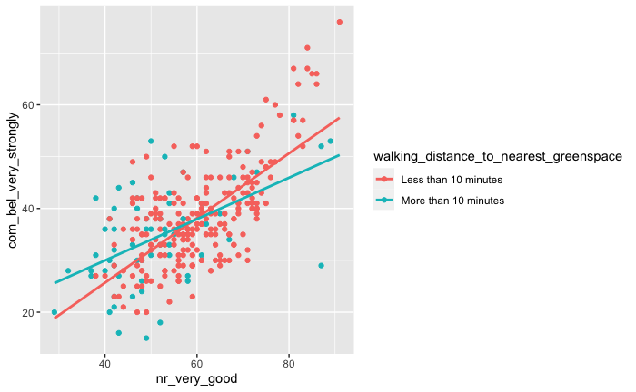

```r
just_walking_distance_neigh_comm %>%
  filter(walking_distance_to_nearest_greenspace != "Don't Know") %>%
  ggplot() +
  aes(x = nr_very_good, y = com_bel_very_strongly, color = walking_distance_to_nearest_greenspace) +
  geom_point() +
  geom_smooth(method = lm, se = FALSE, fullrange = TRUE)
```

```r
just_walking_distance_neigh_comm %>%
  dplyr::filter(walking_distance_to_nearest_greenspace != "Don't Know") %>%
  plot_ly( x = ~nr_very_good, y = ~com_bel_very_strongly, z = ~walking_distance_to_nearest_greenspace,type = "scatter3d", mode = "markers", color = ~walking_distance_to_nearest_greenspace)
```

[output not shown]